# Figure S3D & S3E — Pancreatic T/NK gene programs scored on the Massier adipose lymphocyte atlas

## Source & provenance

- **Source script:** `Reviewer3/adipose_data/T_Cells_Adipose.R` (full path: `~/farber-lab/spw13/Pancreas_Project/NatComm_Reply/Reviewer3/adipose_data/T_Cells_Adipose.R`).
- **Data:** the Massier et al. 2023 adipose **lymphocyte** Seurat object `ly.rds`, derived from the **public GEO dataset GSE225700**. Clusters `lyC0–lyC10` are Massier’s, not our organ-donor cells, so **no donor PII** is present in this analysis or its outputs.
- **Reproducibility status:** all R chunks below are `eval=FALSE` — they show the exact code but are **not executed**. The figures are the **already-generated published PDFs** (rendered to PNG for HTML display); nothing is re-run.
- **Variant note:** the live code lives in `T_Cells_Adipose.R` (lines 691–1605; lines 1–690 are a commented-out earlier draft) and in byte-equivalent twins `T_cells/T_Cells_SC_only)Adipose_29Feb.R` and `T_Cells_Adipose_15Fev.R`.

## Figure S3D — DotPlot of T/NK subsets (3 gene programs)

Dot plot of the Chemotaxis / Cytotoxic-function / Negative-regulation programs across the adipose lymphoid subsets (`CD4+ Th1 … lyC07 … lyC10`). Dot fill = scaled expression, dot size = % of cells in group. **Code from §4b of `T_Cells_Adipose.R`:**

```r
# --- 32 published genes, grouped by the three Figure-3C programs ---
genes_trm_paper <- c(
  # Negative regulation
  "NR3C1", "BTG2", "NFKBIA", "ANXA1", "DUSP1", "BTG1", "ZFP36",
  "ZFP36L2", "TNFAIP3", "TSC22D3",
  # Cytotoxic function
  "NKG7", "IL2RG", "GZMH", "GZMB", "FASLG", "CTSW", "GZMA",
  "IL32", "GLUL", "PRF1", "CD2", "KLRC1", "ZNF683",
  # Chemotaxis
  "CCR9", "CXCR4", "GPR183", "CCR5", "CCR1", "CCR2",
  "CXCR3", "CXCR6", "GPR25"
)
genes_trm_paper <- genes_trm_paper[genes_trm_paper %in% rownames(ly_seurat)]

# 1) Summarised data from Seurat's DotPlot (clusters relabelled to Massier_group)
p_tmp <- DotPlot(
  ly_seurat,
  features  = genes_trm_paper,
  group.by  = "Massier_group",
  dot.scale = 5
)
df <- p_tmp$data
df$id <- factor(df$id, levels = levels(ly_seurat$Massier_group))

# Source-data CSV for Nature requirements
df_export <- df[, c("id", "features.plot", "avg.exp", "avg.exp.scaled", "pct.exp")]
colnames(df_export) <- c("Cluster", "Gene", "Avg_Expression", "Scaled_Expression", "Pct_Expressed")
write.csv(df_export, file = file.path(plot_dir, "SourceData_DotPlot_TRM_genes.csv"), row.names = FALSE)

# 2) Rebuild ggplot: shape-21 filled circles, blue–white–red scaled expression
library(ggplot2)
p_dot_pub <- ggplot(df, aes(x = id, y = features.plot)) +
  geom_point(aes(size = pct.exp, fill = avg.exp.scaled),
             shape = 21, colour = "black", stroke = 0.2) +
  scale_fill_gradient2(low = "#2166ac", mid = "white", high = "#b2182b",
                       midpoint = 0, name = "Scaled\nexpression") +
  scale_size(range = c(0, 6), name = "Fraction\nin group (%)") +
  theme_bw(base_size = 9) +
  theme(panel.grid = element_blank(),
        axis.text.x = element_text(angle = 45, hjust = 1, size = 11),
        axis.text.y = element_text(face = "bold", size = 11),
        axis.title  = element_blank(), legend.position = "right")

ggsave(file.path(plot_dir, "DotPlot_TRM_genes_red_blue_blackframe.pdf"),
       plot = p_dot_pub, width = 8, height = 16, dpi = 300)
# (An annotated-margin variant 'DotPlot_TRM_genes_red_blue_blackframe_annotated.pdf'
#  is also produced further down in §4b — omitted here for brevity.)
```

> **Note (Option A — code is illustrative, embedded figure is authoritative):** the saved script also defines a 5-module gene set (it adds a `Costimulatory` and a 25-gene `Obesity IFN` module used by the heatmap below); the **published S3D panel uses the 3-program (32-gene) subset** shown above. The authoritative published file is `DotPlot_Fig3C_genes_red_blue_blackframe.pdf` (the same 32-gene 3-program plot, produced from an edited-but-unsaved run of this code); the script’s own `ggsave` writes the equivalent `DotPlot_TRM_genes_red_blue_blackframe.pdf`. The embedded figure below is the published one.

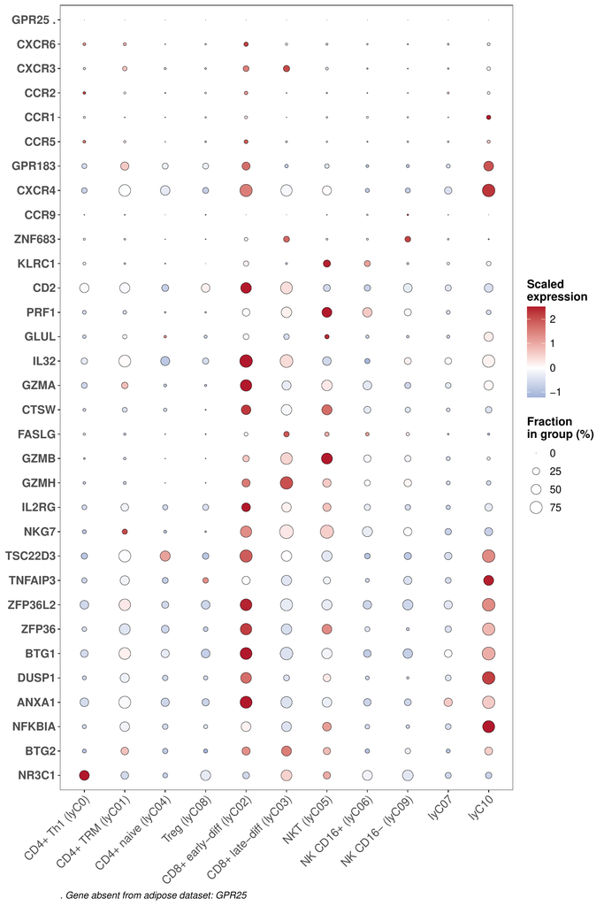

Figure S3D (published): DotPlot_Fig3C_genes_red_blue_blackframe.pdf

## Figure S3E — Module-score heatmap

`AddModuleScore` per program × adipose lymphoid subset, drawn as a `geom_tile` heatmap. **Code from §5–8 of `T_Cells_Adipose.R`:**

```r
# --- module gene sets (script defines 5; published panel uses 3) ---
gene_groups <- list(
  TRM_Cytotoxic_Effector = c("ZNF683","KLRC1","CD2","PRF1","GLUL","IL32",
                             "GZMA","CTSW","FASLG","GZMB","GZMH","IL2RG","NKG7"),
  TRM_Chemotaxis        = c("GPR25","CXCR6","CXCR3","CCR2","CCR1","CCR5",
                            "GPR183","CXCR4","CCR9"),
  TRM_Costimulatory     = c("CD2","CD28","ICOS"),                    # extra (Fig 3B), not in S3E
  TRM_Immunoreg_Brakes  = c("TSC22D3","TNFAIP3","ZFP36L2","ZFP36","BTG1",
                            "DUSP1","ANXA1","NFKBIA","BTG2","NR3C1"),
  TRM_Obesity_IFN       = c("STAT3","MX1","MX2","CD7","IFI30","PLSCR1","CD74","IL6",
                            "ICAM1","TIMP1","SOD2","TYROBP","CMPK2","METRNL","CSF3",
                            "VEGFA","SOCS3","HLA-DRA","IFITM1","S1PR4","G0S2","KLF2",
                            "TRAF1","DDX58","NFKB2")                 # extra (Fig 3E), not in S3E
)
gene_groups_filt <- lapply(gene_groups, function(g) g[g %in% rownames(ly_seurat)])
gene_groups_filt <- gene_groups_filt[sapply(gene_groups_filt, length) >= 2]

ly_seurat <- AddModuleScore(object = ly_seurat, features = gene_groups_filt,
                            name = names(gene_groups_filt), assay = "RNA",
                            nbin = 24, ctrl = 100)

score_cols <- grep(paste0("^(", paste(names(gene_groups_filt), collapse = "|"), ")"),
                   colnames(ly_seurat@meta.data), value = TRUE)

# mean score per cluster -> long format
scores_by_cluster <- ly_seurat@meta.data %>%
  group_by(Massier_group) %>%
  summarise(n_cells = n(), across(all_of(score_cols), mean, .names = "{.col}")) %>%
  arrange(Massier_group)
scores_long <- scores_by_cluster %>% select(-n_cells) %>%
  pivot_longer(cols = all_of(score_cols), names_to = "Module", values_to = "Score")
scores_long$Module <- gsub("[0-9]+$", "", scores_long$Module)

module_order <- rev(c("TRM_Cytotoxic_Effector","TRM_Chemotaxis","TRM_Costimulatory",
                      "TRM_Immunoreg_Brakes","TRM_Obesity_IFN"))
module_order <- module_order[module_order %in% unique(scores_long$Module)]
scores_long$Module <- factor(scores_long$Module, levels = module_order)

p_module_heatmap <- ggplot(scores_long, aes(x = Massier_group, y = Module, fill = Score)) +
  geom_tile(color = "grey90", linewidth = 0.3) +
  scale_fill_gradient2(low = "#2166ac", mid = "white", high = "#b2182b",
                       midpoint = 0, name = "Module\nscore") +
  theme_bw(base_size = 9) +
  theme(axis.text.x = element_text(angle = 45, hjust = 1, size = 11),
        axis.title = element_blank(), panel.grid = element_blank())

ggsave(file.path(plot_dir, "TRM_ModuleScores_heatmap.pdf"),
       plot = p_module_heatmap, width = 8, height = 4, dpi = 300)
```

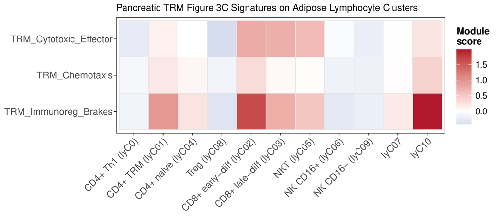

Figure S3E (published): Fig3C_ModuleScores_heatmap.pdf

### Not included: CCL5 / TCF7 / TNFAIP3 UMAP feature plots

The CCL5 / TCF7 / TNFAIP3 UMAP feature plots that appear on the same figure page have **no saved generating script** anywhere in `Reviewer3/adipose_data/`. They are intentionally **not reproduced here** — no code is fabricated for them. If they are required for deposit, the generating script must be located or re-created separately.